# Exercise_12_Dec9_2019_Anara_Alshanbayeva

```r
suppressPackageStartupMessages(library(dplyr))
suppressPackageStartupMessages(library(muscat))
```

```r
suppressPackageStartupMessages(library(diffcyt))
suppressPackageStartupMessages(library(rrcov))
suppressPackageStartupMessages(library(CATALYST))
suppressPackageStartupMessages(library(ExperimentHub))
suppressPackageStartupMessages(library(moveHMM))
suppressPackageStartupMessages(library(cowplot))
suppressPackageStartupMessages(library(flowCore))
suppressPackageStartupMessages(library(scater))
suppressPackageStartupMessages(library(SingleCellExperiment))
suppressPackageStartupMessages(library(ExperimentHub))
suppressPackageStartupMessages(library(ggplot2))
suppressPackageStartupMessages(library(Seurat))
suppressPackageStartupMessages(library(UpSetR))
suppressPackageStartupMessages(library(PCAtools))
suppressPackageStartupMessages(library(mclust))
suppressPackageStartupMessages(library(clue))
suppressPackageStartupMessages(library(plyr))
```

#### Question 1.

#### Grab a well-known dataset, the Zheng 10x PBMC pre-sorted dataset,

#### from ExperimentHub (see code below). Explore basic properties of this dataset,

#### including the number cells of each subpopulation (see the phenoid column of the colData),

#### the depth of sequencing by subpopulation and other aspects you can think of.

#### Re-investigate the filtering (some was already) by plotting

#### the percentage of mitochondrial reads versus the total number of reads.

#### If appropriate, additionally filter any outlier cells.

```r
eh <- ExperimentHub()
```

```
## snapshotDate(): 2019-10-22
```

```r
sce <- eh[["EH1532"]]
```

```
## snapshotDate(): 2019-10-22
```

```
## see ?DuoClustering2018 and browseVignettes('DuoClustering2018') for documentation
```

```
## loading from cache
```

```r
rownames(sce) <- paste0(rowData(sce)$id, "_", rowData(sce)$symbol)
sce
```

```
## class: SingleCellExperiment
## dim: 15716 3994
## metadata(1): log.exprs.offset
## assays(3): counts logcounts normcounts
## rownames(15716): ENSG00000237683_AL627309.1
##   ENSG00000228327_RP11-206L10.2 ... ENSG00000215700_PNRC2
##   ENSG00000215699_SRSF10
## rowData names(10): id symbol ... total_counts log10_total_counts
## colnames(3994): b.cells1147 b.cells6276 ... naive.t1167 naive.t4926
## colData names(14): dataset barcode ... libsize.drop feature.drop
## reducedDimNames(2): PCA TSNE
## spikeNames(0):
## altExpNames(0):
```

#### Investigating the data:

#### We can extract the subpopulations’ names through sce@colData:

```r
populations=sce@colData@listData[["phenoid"]]
populations2=as.data.frame(sce@colData@listData[["phenoid"]])
 unique(populations2)
```

```
##      sce@colData@listData[["phenoid"]]
## 1                              b.cells
## 500                    naive.cytotoxic
## 898                     cd14.monocytes
## 1498                      regulatory.t
## 1996                      cd4.t.helper
## 2396                           cd56.nk
## 2996                          memory.t
## 3496                           naive.t
```

```r
b_cell=sum(populations=="b.cells",value=TRUE)
naive_cytotoxic=sum(populations=="naive.cytotoxic",value=TRUE)
cd14_monocytes=sum(populations=="cd14.monocytes",value=TRUE)
regulatory_t=sum(populations=="regulatory.t",value=TRUE)
cd4_t_helper=sum(populations=="cd4.t.helper",value=TRUE)
cd56_nk=sum(populations=="cd56.nk",value=TRUE)
memory_t=sum(populations=="memory.t",value=TRUE)
naive_t=sum(populations=="naive.t",value=TRUE)

b_cell
```

```
## [1] 500
```

```r
naive_cytotoxic
```

```
## [1] 399
```

```r
cd14_monocytes
```

```
## [1] 601
```

```r
regulatory_t
```

```
## [1] 499
```

```r
cd4_t_helper
```

```
## [1] 401
```

```r
cd56_nk
```

```
## [1] 601
```

```r
memory_t
```

```
## [1] 501
```

```r
naive_t
```

```
## [1] 500
```

```r
total_counts=sce@colData@listData[["total_counts"]]
bcell_depth=sum(total_counts[1:499])
naive_cytotoxic_depth=sum(total_counts[500:897])
cd14_monocytes_depth=sum(total_counts[898:1497])
regulator_t_cell=sum(total_counts[1498:1995])
cd4_t_helper_depth=sum(total_counts[1996:2395])
cd56nk_depth=sum(total_counts[2396:2995])
memory_t_depth=sum(total_counts[2996:3495])
naive_t_depth=sum(total_counts[3496:3908])
```

#### Plotting percentage of mitochondrial genes mapped vs. total counts:

```r
(mito <- grep("MT-", rownames(sce), value = TRUE))
```

```
##  [1] "ENSG00000198888_MT-ND1"  "ENSG00000198763_MT-ND2"
##  [3] "ENSG00000198804_MT-CO1"  "ENSG00000198712_MT-CO2"
##  [5] "ENSG00000228253_MT-ATP8" "ENSG00000198899_MT-ATP6"
##  [7] "ENSG00000198938_MT-CO3"  "ENSG00000198840_MT-ND3"
##  [9] "ENSG00000212907_MT-ND4L" "ENSG00000198886_MT-ND4"
## [11] "ENSG00000198786_MT-ND5"  "ENSG00000198695_MT-ND6"
## [13] "ENSG00000198727_MT-CYB"
```

```r
df <- perCellQCMetrics(sce, subsets=list(Mito=mito))
df
```

```
## DataFrame with 3994 rows and 10 columns
##            sum  detected   percent_top_50  percent_top_100  percent_top_200
##      <numeric> <integer>        <numeric>        <numeric>        <numeric>
## 1         1096       427 48.1751824817518 66.7883211678832 79.2883211678832
## 2          857       340 51.1085180863477 69.0781796966161 83.6639439906651
## 3         1593       602 46.2649089767734 63.0257376020088 74.7645951035782
## 4          743       410 42.7994616419919 57.8734858681023 71.7362045760431
## 5         1031       411 51.0184287099903 67.3132880698351 79.5344325897187
## ...        ...       ...              ...              ...              ...
## 3990      1259       545 43.6060365369341 59.0945194598888 72.5972994440032
## 3991      1259       504 46.6243050039714 62.6687847498014 75.8538522637014
## 3992      1290       614 41.0077519379845 55.0387596899225  67.906976744186
## 3993       805       365 49.9378881987578 64.9689440993789 79.5031055900621
## 3994      1224       498 46.6503267973856 63.1535947712418 75.6535947712418
##       percent_top_500 subsets_Mito_sum subsets_Mito_detected
```

[output cut: 25 more lines]

```r
discard.mito <- isOutlier(df$subsets_Mito_percent, type="higher")
summary(discard.mito)
```

```
##    Mode   FALSE    TRUE
## logical    3908      86
```

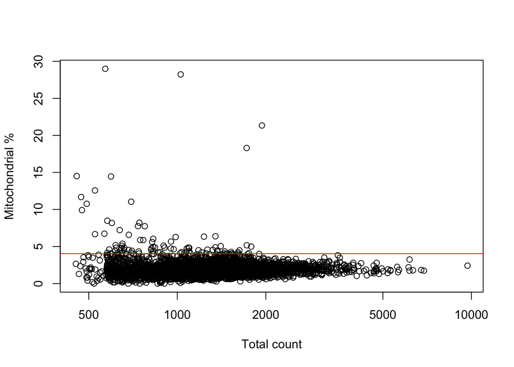

```r
plot(df$sum, df$subsets_Mito_percent, log="x",
     xlab="Total count", ylab='Mitochondrial %')
abline(h=attr(discard.mito, "thresholds")["higher"], col="red")
```

#### Keeping the columns we DON’T want to discard (and removing all cells that have high mitochnodnrial gene content):

```r
filtered <- sce[,!discard.mito]
sce=filtered
```

#### After filtering, we need to normalize our data as well:

```r
library(scran)
clusters <- quickCluster(sce)
sce <- computeSumFactors(sce, cluster=clusters)
sce <- logNormCounts(sce)
```

#### Question 2.

#### Identify “features of interest”, which usually means highly variable genes.

#### There are various ways to do this (e.g., Seurat’s FindVariableFeatures or scran’s modelGeneVar).

#### Select features in at least two ways (say, 1000-2000 genes) and make an upset plot to compare the lists.

#### Quantifying per gene variation by variance of the log-counts:

#### Variance in the PBMC data set as a function of the mean.

#### Each point represents a gene while the red line represents the trend fitted to all genes.

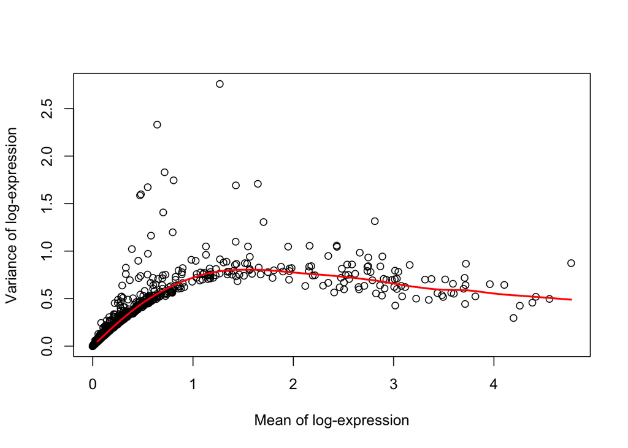

```r
suppressPackageStartupMessages(library(scran))
dec.pbmc <- modelGeneVar(sce)
fit.pbmc <- metadata(dec.pbmc)
plot(fit.pbmc$mean, fit.pbmc$var, xlab="Mean of log-expression",
     ylab="Variance of log-expression")
curve(fit.pbmc$trend(x), col="red", add=TRUE, lwd=2)
```

#### Ordering by most interesting genes for inspection.

```r
dec.pbmc[order(dec.pbmc$bio, decreasing=TRUE),]
```

```
## DataFrame with 15716 rows and 6 columns
##                                      mean             total              tech
##                                 <numeric>         <numeric>         <numeric>
## ENSG00000019582_CD74     1.26698432355672  2.75906844745024  0.78809703516079
## ENSG00000115523_GNLY    0.642772142981735  2.33066215577129 0.550083372872189
## ENSG00000204287_HLA-DRA 0.716724135570216  1.82940429400051 0.592250004310302
## ENSG00000105374_NKG7    0.548361854651785   1.6723879097425 0.489141108715497
## ENSG00000163220_S100A9  0.480825021994862  1.59797370473845 0.440425742672937
## ...                                   ...               ...               ...
## ENSG00000164587_RPS14    3.71234029501545 0.443365378337688 0.588822235754697
## ENSG00000161970_RPL26    2.88379919985662 0.531170687618529 0.678867823096022
## ENSG00000204525_HLA-C    2.40737766857347 0.564850965376023 0.739479331559505
## ENSG00000234745_HLA-B    3.01645213515939 0.426848384229158 0.655632141113403
## ENSG00000205542_TMSB4X   4.19538226391375 0.295851622534648 0.535342335136385
##                                        bio               p.value
##                                  <numeric>             <numeric>
## ENSG00000019582_CD74      1.97097141228945  1.36639655602232e-67
## ENSG00000115523_GNLY       1.7805787828991 9.65608322207609e-112
## ENSG00000204287_HLA-DRA   1.23715428969021  8.59167142371331e-48
## ENSG00000105374_NKG7        1.183246801027  2.24757922604068e-63
## ENSG00000163220_S100A9    1.15754796206551  2.01293348950887e-74
## ...                                    ...                   ...
## ENSG00000164587_RPS14   -0.145456857417009     0.956542847152464
## ENSG00000161970_RPL26   -0.147697135477493      0.93418495858142
## ENSG00000204525_HLA-C   -0.174628366183482     0.949133384207616
## ENSG00000234745_HLA-B   -0.228783756884245     0.992201514284188
## ENSG00000205542_TMSB4X  -0.239490712601737     0.999032976771747
##                                           FDR
##                                     <numeric>
## ENSG00000019582_CD74     5.35764089616352e-64
## ENSG00000115523_GNLY    1.51446009255041e-107
## ENSG00000204287_HLA-DRA  2.24586291015866e-44
## ENSG00000105374_NKG7      7.0502065162444e-60
## ENSG00000163220_S100A9   1.05236162831524e-70
## ...                                       ...
## ENSG00000164587_RPS14       0.999999998883139
## ENSG00000161970_RPL26       0.986197681733102
## ENSG00000204525_HLA-C       0.997400870881892
## ENSG00000234745_HLA-B       0.999999998883139
## ENSG00000205542_TMSB4X      0.999999998883139
```

```r
order_dec_pbmc=dec.pbmc[order(dec.pbmc$bio, decreasing=TRUE),]
FDR=as.data.frame(order_dec_pbmc@listData[["FDR"]])
FDR_0.05_method1 <- subset(FDR, order_dec_pbmc@listData[["FDR"]]< 0.05 )
```

#### Quantifying per gene variation by Squared coefficient of variation:

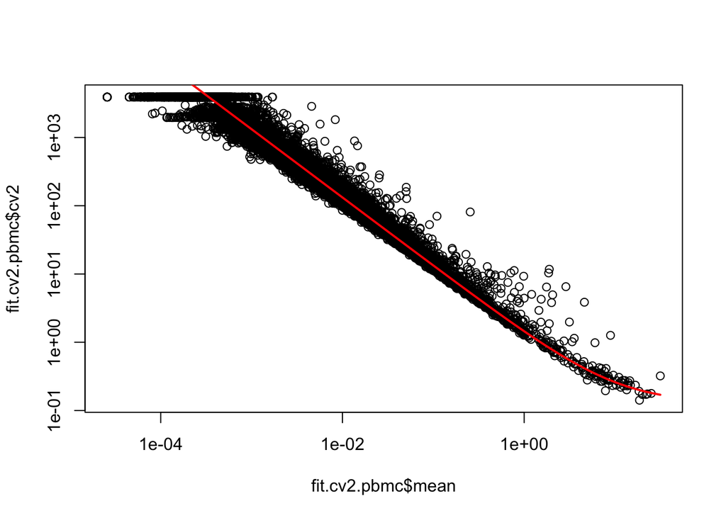

```r
dec.cv2.pbmc <- modelGeneCV2(sce)
fit.cv2.pbmc <- metadata(dec.cv2.pbmc)
plot(fit.cv2.pbmc$mean, fit.cv2.pbmc$cv2, log="xy")
curve(fit.cv2.pbmc$trend(x), col="red", add=TRUE, lwd=2)
```

#### The deviation for each gene from the trend:

```r
dec.cv2.pbmc[order(dec.cv2.pbmc$ratio, decreasing=TRUE),]
```

```
## DataFrame with 15716 rows and 6 columns
##                                              mean            total
##                                         <numeric>        <numeric>
## ENSG00000254709_IGLL5           0.254748698723424 81.1148561146194
## ENSG00000143546_S100A8           1.88831469197569 11.7423441527899
## ENSG00000163220_S100A9           1.85716981538324 10.3629676025685
## ENSG00000115568_ZNF142        0.00833598851363301 1824.44732765433
## ENSG00000115523_GNLY             2.87711452073641 6.52476979129587
## ...                                           ...              ...
## ENSG00000267723_CTD-2189E23.1                   0              NaN
## ENSG00000153902_LGI4                            0              NaN
## ENSG00000075702_WDR62                           0              NaN
## ENSG00000273203_AC006946.16                     0              NaN
## ENSG00000234884_CTA-407F11.8                    0              NaN
##                                           trend            ratio   p.value
##                                       <numeric>        <numeric> <numeric>
## ENSG00000254709_IGLL5          5.31538138644581 15.2604018822547         0
## ENSG00000143546_S100A8        0.827979718984717 14.1819224354778         0
## ENSG00000163220_S100A9        0.839715317223235 12.3410486744921         0
## ENSG00000115568_ZNF142         158.649439965858 11.4998661706399         0
## ENSG00000115523_GNLY          0.587476181317828 11.1064414163303         0
## ...                                         ...              ...       ...
## ENSG00000267723_CTD-2189E23.1               Inf              NaN       NaN
## ENSG00000153902_LGI4                        Inf              NaN       NaN
## ENSG00000075702_WDR62                       Inf              NaN       NaN
## ENSG00000273203_AC006946.16                 Inf              NaN       NaN
## ENSG00000234884_CTA-407F11.8                Inf              NaN       NaN
##                                     FDR
##                               <numeric>
## ENSG00000254709_IGLL5                 0
## ENSG00000143546_S100A8                0
## ENSG00000163220_S100A9                0
## ENSG00000115568_ZNF142                0
## ENSG00000115523_GNLY                  0
## ...                                 ...
## ENSG00000267723_CTD-2189E23.1       NaN
## ENSG00000153902_LGI4                NaN
## ENSG00000075702_WDR62               NaN
## ENSG00000273203_AC006946.16         NaN
## ENSG00000234884_CTA-407F11.8        NaN
```

```r
hvg.pbmc.var <- getTopHVGs(dec.pbmc, n=2000)
str(hvg.pbmc.var)
```

```
##  chr [1:2000] "ENSG00000019582_CD74" "ENSG00000115523_GNLY" ...
```

```r
hvg.pbmc.var.2 <- getTopHVGs(dec.pbmc, fdr.threshold = 0.05)
```

#### Question 3. Re-calculate the low dimensional projection using your preferred set of selected features

#### and produce some visualizations. For example, after re-running PCA, use the scater package to run the UMAP

#### algorithm. Make multiple plots of the UMAP coordinates according to cell type (this is known in advance for

#### this dataset), depth of sequencing and anything else you might find appropriate.

```r
suppressPackageStartupMessages(library(scater))
sce=runPCA(sce,subset_row=hvg.pbmc.var)

percent.var <- attr(reducedDim(sce), "percentVar")
chosen.elbow <- PCAtools::findElbowPoint(percent.var)
chosen.elbow
```

```
## [1] 6
```

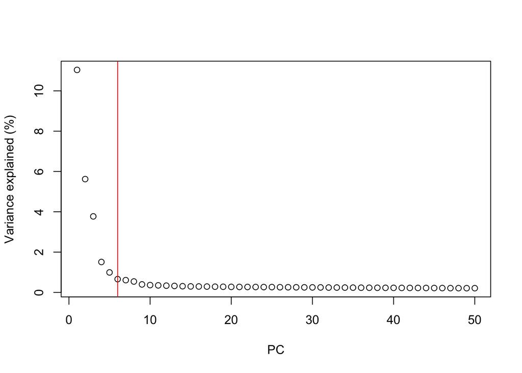

```r
plot(percent.var, xlab="PC", ylab="Variance explained (%)")
abline(v=chosen.elbow, col="red")
```

```r
reducedDim(sce, "PCA") <- reducedDim(sce, "PCA")[,1:10]
ncol(reducedDim(sce, "PCA"))
```

```
## [1] 10
```

```r
reducedDim(sce, "PCA_10") <- reducedDim(sce, "PCA")[,1:10]
reducedDimNames(sce)
```

```
## [1] "PCA"    "TSNE"   "PCA_10"
```

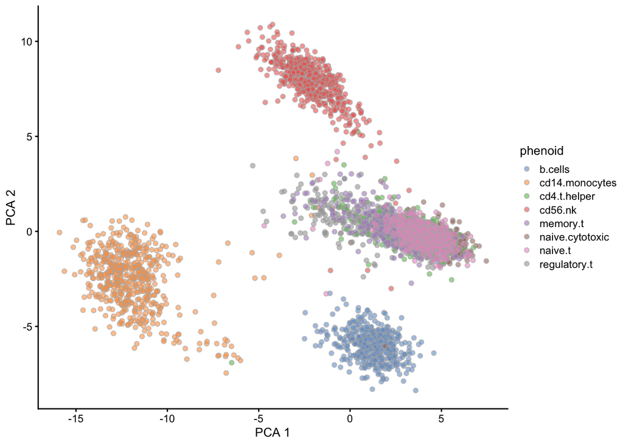

```r
plotReducedDim(sce, dimred="PCA",colour_by = "phenoid")
```

```r
sce<- runUMAP(sce, dimred="PCA")
reducedDimNames(sce)
```

```
## [1] "PCA"    "TSNE"   "PCA_10" "UMAP"
```

```r
dim(reducedDim(sce, "UMAP"))
```

```
## [1] 3908    2
```

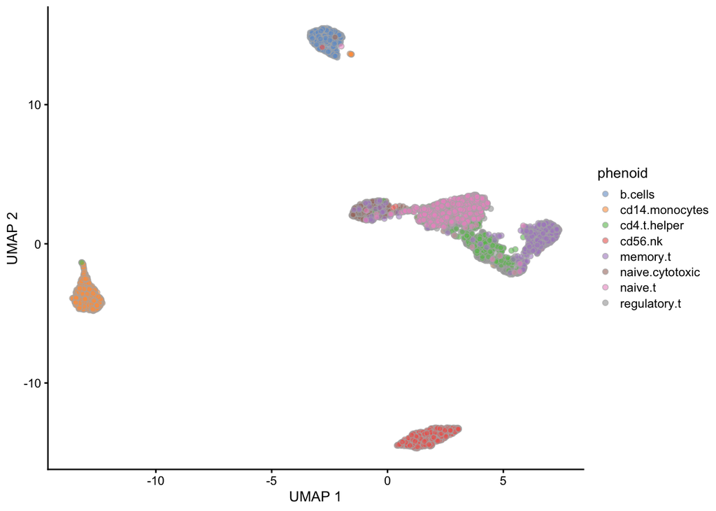

```r
plotReducedDim(sce, dimred="UMAP",colour_by = "phenoid")
```

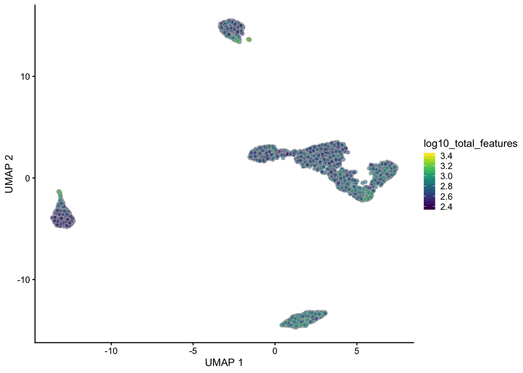

```r
plotReducedDim(sce, dimred="UMAP",colour_by = "log10_total_features")
```

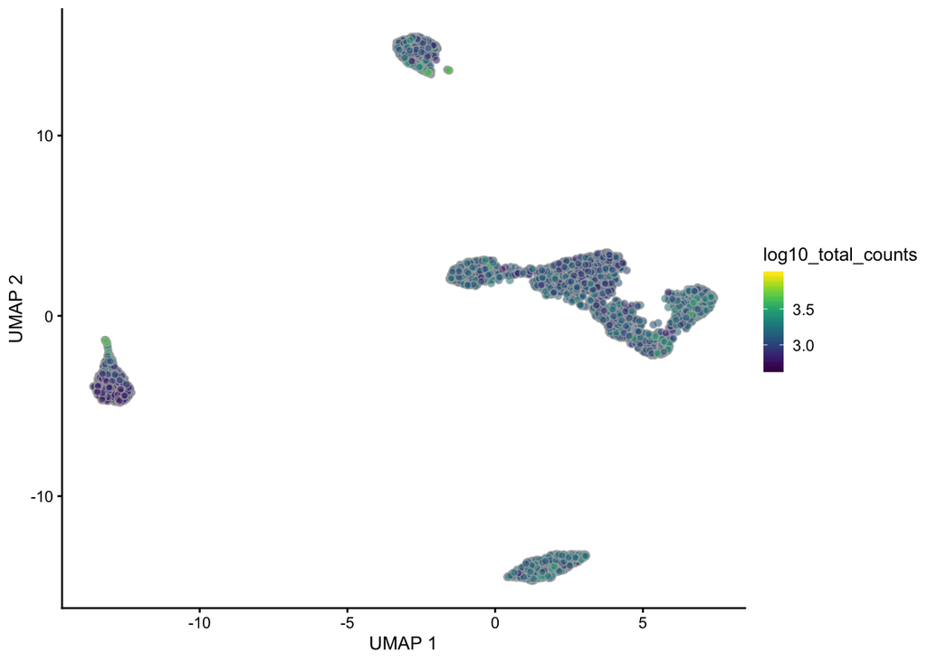

```r
plotReducedDim(sce, dimred="UMAP",colour_by = "log10_total_counts")
```

#### Question 4. Run at least 2 algorithms to cluster the data and make some comparisons.

#### One should be graph-based clustering as this seems to perform well, generally speaking.

#### Calculate the F1 score for each cell type (solve_LSAP in the clue package may be useful for matching

#### of clsuters to true populations) and the adjusted rand index (adjustedRandIndex in the mclust package,

#### for example) for an overall score. What cell types are more difficult to separate with clustering?

#### Run one of the algorithms at different numbers of clusters and plot a curve of the performance

#### (e.g., adjusted rand index) as a function of the number of clusters.

#### First of the 2 algorithms for clustering - the graph based clustering.

```r
suppressPackageStartupMessages(library(scran))
g <- buildSNNGraph(sce, k=18, use.dimred = 'PCA')
clust <- igraph::cluster_walktrap(g)$membership
table(clust)
```

```
## clust
##   1   2   3   4   5   6   7   8   9
## 534 574 484 819  30 467 449 405 146
```

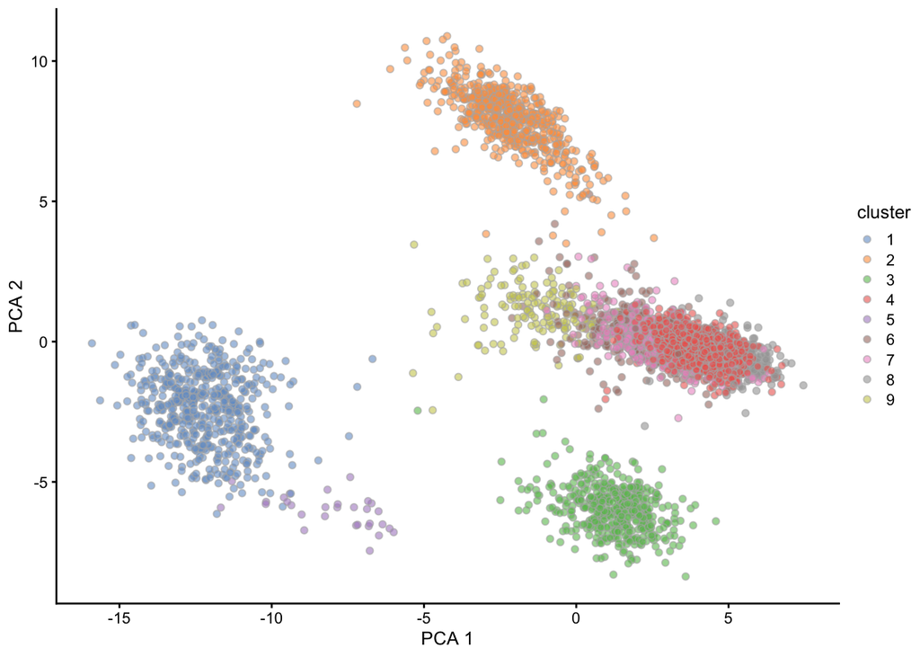

```r
suppressPackageStartupMessages(library(scater))
sce$cluster <- factor(clust)
plotReducedDim(sce, "PCA", colour_by="cluster")
```

#### Second of the 2 algorithms for clustering - K-means custering:

```r
sce1=sce
clust.kmeans <- kmeans(reducedDim(sce, "PCA"), centers=7)
table(clust.kmeans$cluster)
```

```
##
##   1   2   3   4   5   6   7
## 808  98 608 573 870 483 468
```

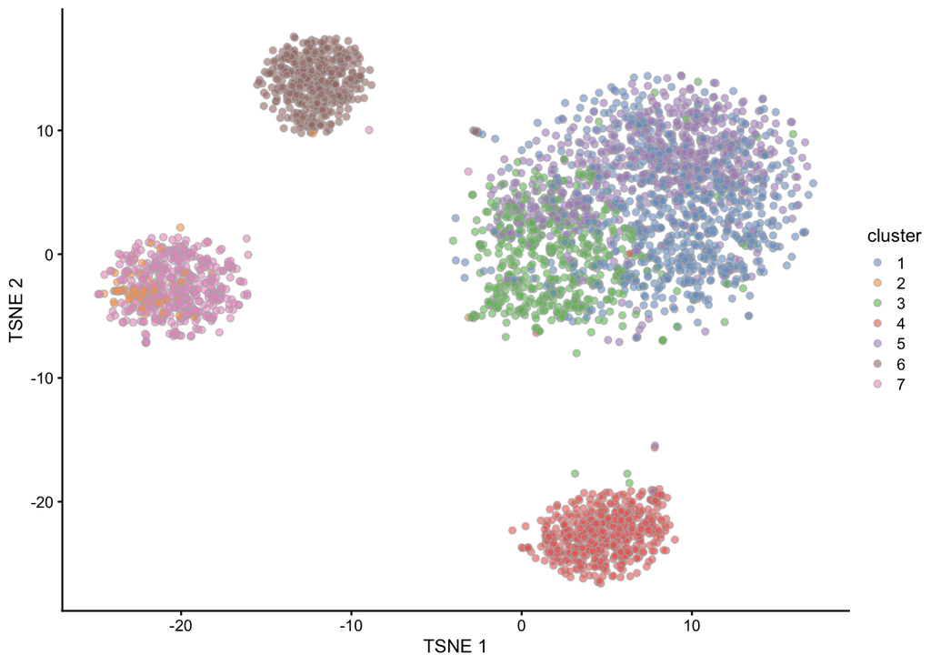

```r
sce1$cluster <- factor(clust.kmeans$cluster)
plotReducedDim(sce1, "TSNE", colour_by="cluster")
```

#### Calculating the adjusted Rand Index of the clusters generated by PCA & k-means:

```r
adjustedRandIndex(sce$cluster,clust.kmeans$cluster)
```

```
## [1] 0.6816824
```

#### Run one of the algorithms at different numbers of clusters and plot a curve of the performance

#### (e.g., adjusted rand index) as a function of the number of clusters.

```r
suppressPackageStartupMessages(library(scran))
g <- buildSNNGraph(sce, k=2, use.dimred = 'PCA')
clust <- igraph::cluster_walktrap(g)$membership
table(clust)
```

```
## clust
##   1   2   3   4   5   6   7   8   9  10  11  12  13  14  15  16  17  18  19  20
##  84 348  65 143 184  62 110  25 243  19  52  99 191  33  60 345  29 331  26 231
##  21  22  23  24  25  26  27  28  29  30  31  32  33  34  35  36  37  38  39  40
##  31  99  51 119  15  84 239  21  37  39  10  25  21  55  14  21  11  12  11  17
##  41  42  43  44  45  46  47  48  49  50  51  52  53  54  55  56  57  58  59  60
##  10  15  11   9   8  26  18   9  11   6  11  10  13  13   6   6   6   8   6   6
##  61  62  63  64  65  66  67  68  69  70  71  72  73  74  75  76  77  78  79  80
##   3   5   6   3   8   4   3   4   8   5   4   5   4   3   4   5   5   3   3   3
```

```r
suppressPackageStartupMessages(library(scater))
sce$cluster <- factor(clust)
k2value=adjustedRandIndex(sce$cluster,clust.kmeans$cluster)
k2clusters=nrow(unique(as.data.frame(clust)))

g <- buildSNNGraph(sce, k=3, use.dimred = 'PCA')
clust <- igraph::cluster_walktrap(g)$membership
table(clust)
```

```
## clust
##   1   2   3   4   5   6   7   8   9  10  11  12  13  14  15  16  17  18  19  20
##  54 459 498 441 440 394 217 478  75 372 256  57  35  44  37  14  11  15   6   5
```

```r
suppressPackageStartupMessages(library(scater))
sce$cluster <- factor(clust)
k3value=adjustedRandIndex(sce$cluster,clust.kmeans$cluster)
k3clusters=nrow(unique(as.data.frame(clust)))

g <- buildSNNGraph(sce, k=4, use.dimred = 'PCA')
clust <- igraph::cluster_walktrap(g)$membership
table(clust)
```

```
## clust
##   1   2   3   4   5   6   7   8   9  10  11  12  13  14
## 499 473 102 401  29 443 453 466 396 445  81  73  42   5
```

```r
suppressPackageStartupMessages(library(scater))
sce$cluster <- factor(clust)
k4value=adjustedRandIndex(sce$cluster,clust.kmeans$cluster)
k4clusters=nrow(unique(as.data.frame(clust)))


g <- buildSNNGraph(sce, k=5, use.dimred = 'PCA')
clust <- igraph::cluster_walktrap(g)$membership
table(clust)
```

```
## clust
##   1   2   3   4   5   6   7   8   9  10  11  12  13
## 114 442 496 445 396 444 457 486  29  77 406  76  40
```

```r
suppressPackageStartupMessages(library(scater))
sce$cluster <- factor(clust)
k5value=adjustedRandIndex(sce$cluster,clust.kmeans$cluster)
k5clusters=nrow(unique(as.data.frame(clust)))

g <- buildSNNGraph(sce, k=6, use.dimred = 'PCA')
clust <- igraph::cluster_walktrap(g)$membership
table(clust)
```

```
## clust
##   1   2   3   4   5   6   7   8   9  10  11
## 572 909 479 169 376 357 447 443  29  87  40
```

```r
suppressPackageStartupMessages(library(scater))
sce$cluster <- factor(clust)
k6value=adjustedRandIndex(sce$cluster,clust.kmeans$cluster)
k6clusters=nrow(unique(as.data.frame(clust)))

g <- buildSNNGraph(sce, k=7, use.dimred = 'PCA')
clust <- igraph::cluster_walktrap(g)$membership
table(clust)
```

```
## clust
##   1   2   3   4   5   6   7   8   9  10  11
## 572 878 436 444 211 441 321 441  93  29  42
```

```r
suppressPackageStartupMessages(library(scater))
sce$cluster <- factor(clust)
k7value=adjustedRandIndex(sce$cluster,clust.kmeans$cluster)
k7clusters=nrow(unique(as.data.frame(clust)))


g <- buildSNNGraph(sce, k=8, use.dimred = 'PCA')
clust <- igraph::cluster_walktrap(g)$membership
table(clust)
```

```
## clust
##   1   2   3   4   5   6   7   8   9  10
## 533 572 889 463 417 398 445 123  30  38
```

```r
suppressPackageStartupMessages(library(scater))
sce$cluster <- factor(clust)
k8value=adjustedRandIndex(sce$cluster,clust.kmeans$cluster)
k8clusters=nrow(unique(as.data.frame(clust)))


g <- buildSNNGraph(sce, k=9, use.dimred = 'PCA')
clust <- igraph::cluster_walktrap(g)$membership
table(clust)
```

```
## clust
##   1   2   3   4   5   6   7   8   9
## 485 533 572 871 464 436 412 105  30
```

```r
suppressPackageStartupMessages(library(scater))
sce$cluster <- factor(clust)
k9value=adjustedRandIndex(sce$cluster,clust.kmeans$cluster)
k9clusters=nrow(unique(as.data.frame(clust)))


g <- buildSNNGraph(sce, k=12, use.dimred = 'PCA')
clust <- igraph::cluster_walktrap(g)$membership
table(clust)
```

```
## clust
##   1   2   3   4   5   6   7   8   9  10  11
## 574 905 209 479 410 444 443 283  92  28  41
```

```r
suppressPackageStartupMessages(library(scater))
sce$cluster <- factor(clust)
k12value=adjustedRandIndex(sce$cluster,clust.kmeans$cluster)
k12clusters=nrow(unique(as.data.frame(clust)))

g <- buildSNNGraph(sce, k=13, use.dimred = 'PCA')
clust <- igraph::cluster_walktrap(g)$membership
table(clust)
```

```
## clust
##   1   2   3   4   5   6   7   8
## 484 536 781 574 905 209 391  28
```

```r
suppressPackageStartupMessages(library(scater))
sce$cluster <- factor(clust)
k13value=adjustedRandIndex(sce$cluster,clust.kmeans$cluster)
k13clusters=nrow(unique(as.data.frame(clust)))

g <- buildSNNGraph(sce, k=15, use.dimred = 'PCA')
clust <- igraph::cluster_walktrap(g)$membership
table(clust)
```

```
## clust
##   1   2   3   4   5   6   7   8   9
## 536 484 573 948 201 439 403 296  28
```

```r
suppressPackageStartupMessages(library(scater))
sce$cluster <- factor(clust)
k15value=adjustedRandIndex(sce$cluster,clust.kmeans$cluster)
k15clusters=nrow(unique(as.data.frame(clust)))

g <- buildSNNGraph(sce, k=20, use.dimred = 'PCA')
clust <- igraph::cluster_walktrap(g)$membership
table(clust)
```

```
## clust
##   1   2   3   4   5   6   7
## 925 534 574 484 908  30 453
```

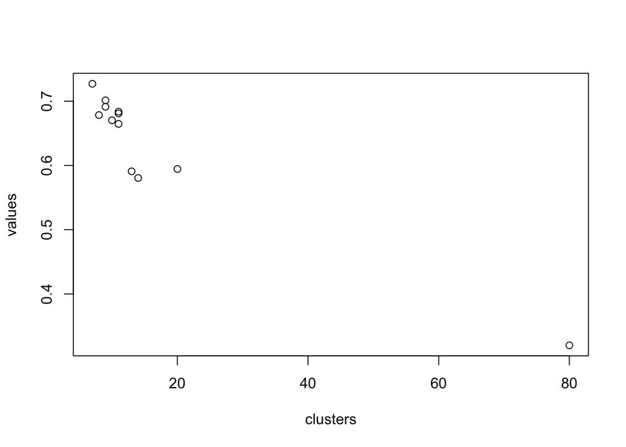

```r
suppressPackageStartupMessages(library(scater))
sce$cluster <- factor(clust)
k20value=adjustedRandIndex(sce$cluster,clust.kmeans$cluster)
k20clusters=nrow(unique(as.data.frame(clust)))

values=data.frame(k2value,k3value,k4value,k5value,k6value,k7value,k8value,k9value,k12value,k13value,k15value,k20value)
clusters=data.frame(k2clusters,k3clusters,k4clusters,k5clusters,k6clusters,k7clusters,k8clusters,k9clusters,k12clusters,k13clusters,k15clusters,k20clusters)
values=as.matrix(values)
clusters=as.matrix(clusters)
plot(clusters,values)
```

#### The cell types that are difficult to separate by clustering are: “cd4.t.helper cells”" and “regulatory t.cells”.